# R Notebook

Regression with categorical predictors: Basically, using regression for a t-test!

Reference: Bodo Winter Chapter 7

```r
library(tidyverse)
library(broom)
```

```r
senses <- read_csv('winter_2016_senses_valence.csv')
senses
```

| Word | Val | AbsVal | Sent | AbsSent | DominantModality |
| --- | --- | --- | --- | --- | --- |
| abrasive | 5.398113 | 0.8437006 | 0.194851852 | 0.4867419 | Touch |
| absorbent | 5.876667 | 0.8867942 | 0.147041667 | 0.5177123 | Sight |
| aching | 5.233370 | 1.1878343 | 0.054022989 | 0.5811500 | Touch |
| acidic | 5.539592 | 1.0944267 | 0.140979167 | 0.5505248 | Taste |
| acrid | 5.173947 | 1.1986031 | 0.279270270 | 0.7524067 | Smell |
| adhesive | 5.240000 | 0.7048216 | 0.191047619 | 0.4277649 | Touch |
| alcoholic | 5.557228 | 1.2972046 | 0.319635417 | 0.5891800 | Taste |
| alive | 6.040952 | 1.1574475 | -0.081378788 | 0.4368016 | Sight |
| amber | 5.720549 | 0.9887231 | 0.509806818 | 0.6794730 | Sight |
| angular | 5.477616 | 0.7712019 | 0.082993056 | 0.5037999 | Sight |

[output cut: 395 more lines]

Preprocessing and visualization to get only the Taste and Smell data getting rows

```r
chem <- filter(senses, DominantModality %in% c('Taste', 'Smell'))
table(chem$DominantModality)
```

```
Smell Taste
   25    47
```

```r
chem %>% group_by(DominantModality) %>%
summarize(M = mean(Val), SD = sd(Val))
```

| DominantModality | M | SD |
| --- | --- | --- |
| Smell | 5.471012 | 0.3357883 |
| Taste | 5.808124 | 0.3033168 |

smell is the reference (based on alphabetical order)

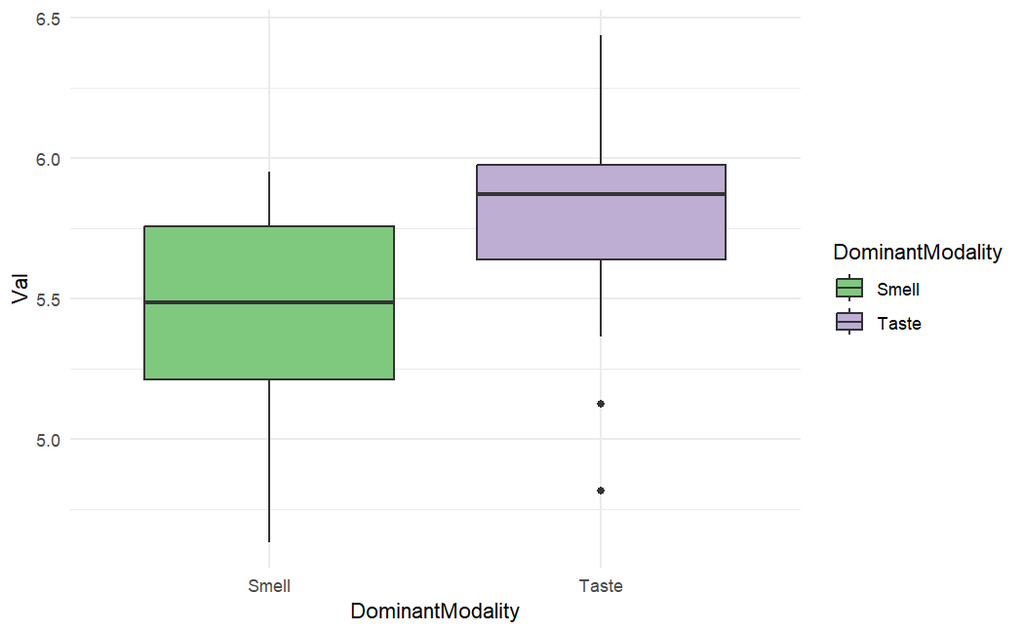

```r
chem %>% ggplot(aes(x = DominantModality, y = Val, fill = DominantModality)) +
geom_boxplot() + theme_minimal() +
scale_fill_brewer(palette = 'Accent')
```

If you are interested in choosing the right colors for your plots, then here’s a good resource https://ggplot2-book.org/scales-colour

smell is the reference coding of variable referred to as treatment coding or dummy smell - 0 taste - 1 intercept as mean of smell

reference is smell and it tells how much it shows in when it changes from smell to taste categorical variables for smell and taste cahange with valence

```r
chem_mdl <- lm(Val ~ DominantModality, data = chem)
summary(chem_mdl)
```

```
Call:
lm(formula = Val ~ DominantModality, data = chem)

Residuals:
     Min       1Q   Median       3Q      Max
-0.99315 -0.20870  0.04343  0.19115  0.62788

Coefficients:
                      Estimate Std. Error t value Pr(>|t|)
(Intercept)            5.47101    0.06297  86.889  < 2e-16 ***
DominantModalityTaste  0.33711    0.07793   4.326 4.95e-05 ***
---
Signif. codes:  0 ‘***’ 0.001 ‘**’ 0.01 ‘*’ 0.05 ‘.’ 0.1 ‘ ’ 1

Residual standard error: 0.3148 on 70 degrees of freedom
Multiple R-squared:  0.2109,    Adjusted R-squared:  0.1997
F-statistic: 18.71 on 1 and 70 DF,  p-value: 4.951e-05
```

Using the predict() to determine the values associated with each predictor

```r
chem_preds <- tibble(DominantModality = unique(chem$DominantModality))
chem_preds
```

| DominantModality |
| --- |
| Taste |
| Smell |

```r
chem_preds$fit <- predict(chem_mdl, chem_preds)
chem_preds
```

| DominantModality | fit |
| --- | --- |
| Taste | 5.808124 |
| Smell | 5.471012 |

0—> 1 Change the reference - from Smell to Taste. factor changes character to numeral gives 0,1 etc to groups

```r
chem <- mutate(chem,
DominantModality = factor(DominantModality),
ModRe = relevel(DominantModality, ref = 'Taste'))
```

Verify reference levels

```r
levels(chem$DominantModality)
```

```
[1] "Smell" "Taste"
```

```r
levels(chem$ModRe)
```

```
[1] "Taste" "Smell"
```

Rerun the regression

```r
lm(Val ~ ModRe, data = chem)
```

```
Call:
lm(formula = Val ~ ModRe, data = chem)

Coefficients:
(Intercept)   ModReSmell
     5.8081      -0.3371
```

Treatment Coding vs Sum Coding:

Treatment Coding: Taste = 0; Smell = 1

Sum Coding: Taste = -1; Smell = 1

Sum Coding is useful esepcially for interpreting interactions.

Fitting categorical data with more than two levels

```r
unique(senses$DominantModality)
```

```
[1] "Touch" "Sight" "Taste" "Smell" "Sound"
```

Uses the entire varibales sight is the default here (the intercept) beacuse of alhabetical order

```r
sense_all <- lm(Val ~ DominantModality, data = senses)
summary(sense_all)
```

```
Call:
lm(formula = Val ~ DominantModality, data = senses)

Residuals:
     Min       1Q   Median       3Q      Max
-0.99315 -0.16482 -0.02158  0.15920  1.15734

Coefficients:
                      Estimate Std. Error t value Pr(>|t|)
(Intercept)            5.57966    0.01889 295.308  < 2e-16 ***
DominantModalitySmell -0.10865    0.05643  -1.925   0.0549 .
DominantModalitySound -0.17447    0.03758  -4.643 4.66e-06 ***
DominantModalityTaste  0.22846    0.04314   5.296 1.96e-07 ***
DominantModalityTouch -0.04523    0.03737  -1.210   0.2269
---
Signif. codes:  0 ‘***’ 0.001 ‘**’ 0.01 ‘*’ 0.05 ‘.’ 0.1 ‘ ’ 1

Residual standard error: 0.2659 on 400 degrees of freedom
Multiple R-squared:  0.1455,    Adjusted R-squared:  0.137
F-statistic: 17.03 on 4 and 400 DF,  p-value: 6.616e-13
```

Using predict to help with interpretation

```r
sense_preds <- tibble(DominantModality = sort(unique(senses$DominantModality)))
sense_preds$fit <- predict(sense_all, sense_preds)
sense_preds
```

| DominantModality | fit |
| --- | --- |
| Sight | 5.579663 |
| Smell | 5.471012 |
| Sound | 5.405193 |
| Taste | 5.808124 |
| Touch | 5.534435 |

Lastly, check assumptions:

Normality test:

```r
library(car)
```

```r
shapiro.test(residuals(sense_all))
```

```
    Shapiro-Wilk normality test

data:  residuals(sense_all)
W = 0.98434, p-value = 0.0002282
```

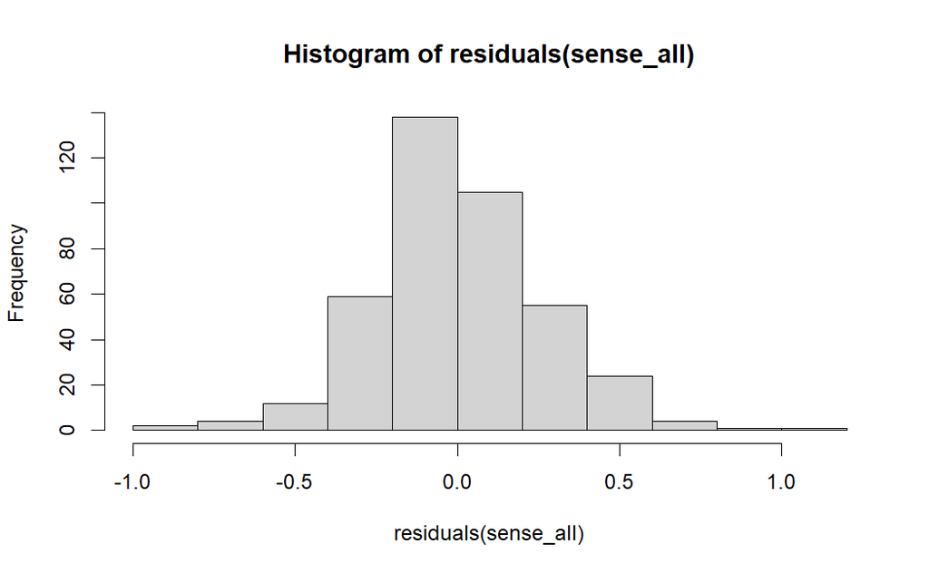

```r
 hist( x = residuals( sense_all ))
```

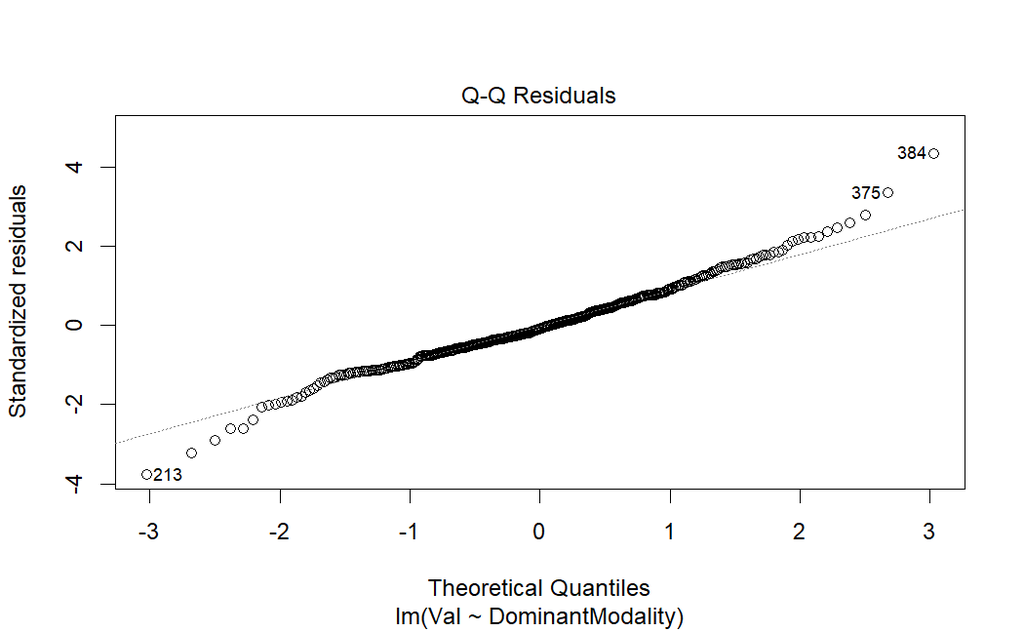

```r
plot( x = sense_all, which = 2 )
```

```r
ncvTest( sense_all )
```

```
Non-constant Variance Score Test
Variance formula: ~ fitted.values
Chisquare = 0.07688406, Df = 1, p = 0.78157
```

Linearity test

```r
library(carData)
```

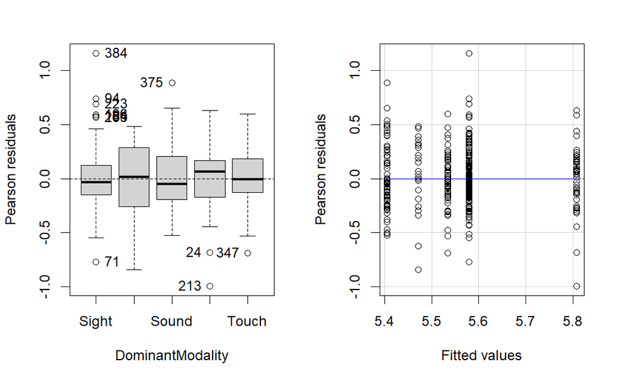

```r
residualPlots( model = sense_all )
```

Lastly, we assess the variance inflation factor – to diagnose for collinearity

```r
car::vif( mod = sense_all )
```

```
Error in vif.default(mod = sense_all) : model contains fewer than 2 terms
```